# Point pattern analysis

```r
library(spatstat)
preston_crime <- readRDS("data/pcrime-spatstat.rds")
summary(preston_crime)
```

```
Marked planar point pattern:  2036 points
Average intensity 4.053214e-05 points per square unit

Coordinates are given to 2 decimal places
i.e. rounded to the nearest multiple of 0.01 units

Multitype:
```

|  | frequency | proportion | intensity |
| --- | --- | --- | --- |
| Non-violent crime | 1812 | 0.8899804 | 3.607281e-05 |
| Violent crime | 224 | 0.1100196 | 4.459332e-06 |

```
Window: polygonal boundary
single connected closed polygon with 99 vertices
enclosing rectangle: [349773, 357771] x [425706.5, 433705.5] units
                     (7998 x 7999 units)
Window area = 50231700 square units
Fraction of frame area: 0.785
```

```r
table(marks(preston_crime))
```

```
Non-violent crime     Violent crime
             1812               224
```

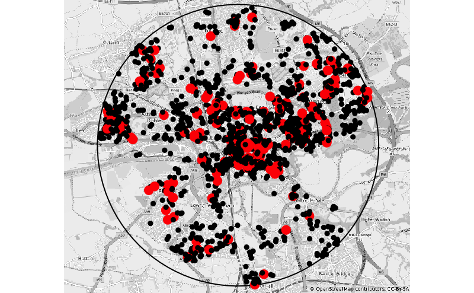

```r
preston_osm <- readRDS("data/osm_preston_gray.rds")
# Define a function to create a map
preston_map <- function(cols=c("green", "red"),
                        cex = c(1, 1), pch=c(1,1)) {
  plotRGB(preston_osm)
  plot(preston_crime, cols = cols, pch = pch, cex = cex, add = TRUE, show.window =TRUE)
}

preston_map(
  cols = c("black", "red"),
  cex = c(0.5, 1),
  pch = c(19, 19)
)
```

### Violent crime proportion estimation

One method of computing a smooth intensity surface from a set of points is to use kernel smoothing. Imagine replacing each point with a dot of ink on an absorbent paper. Each individual ink drop spreads out into a patch with a dark center, and multiple drops add together and make the paper even darker. With the right amount of ink in each drop, and with paper of the right absorbency, you can create a fair impression of the density of the original points. In kernel smoothing jargon, this means computing a bandwidth and using a particular kernel function.

To get a smooth map of violent crimes proportion, we can estimate the intensity surface for violent and non-violent crimes, and take the ratio. To do this with the `density()` function function in `spatstat`. We have to split the points according to the two values of the marks and then compute the ratio of the violent crime surface to the total. The function has sensible defaults for the kernel function and bandwidth to guarantee something that looks at least plausible.

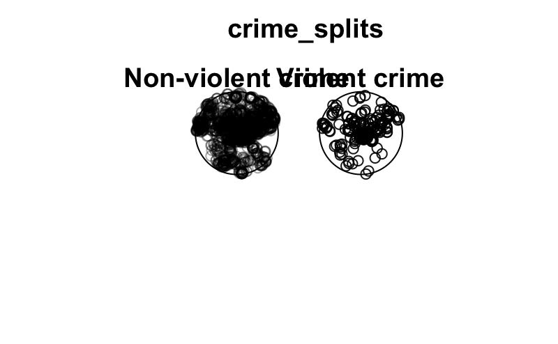

```r
crime_splits <- split(preston_crime)
plot(crime_splits)
```

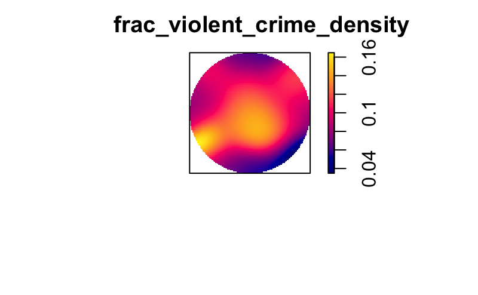

```r
crime_densities <- density(crime_splits)

# Calculate the density of the fraction of violent crimes
frac_violent_crime_density <- crime_densities[["Violent crime"]]/(crime_densities[["Non-violent crime"]] + crime_densities[["Violent crime"]])
plot(frac_violent_crime_density)
```

### Bandwidth selection

We can get a more principled measure of the violent crime ration using spatial segregation model. The `spatialkernel` package implements the theory of spatial segregation.

```r
# library(spatialkernel)
bw_choice <- spseg(
  preston_crime,
  h = seq(500, 1000, by=1000),
  opt = 1
)
```

[output not shown]

### Segregation probabilities

The second step is to compute the probabilities for violent and non-violent crimes as a smooth surface, as well as the p-values for a point-wise test of segregation. This is done by calling spseg() with opt = 3 and a fixed bandwidth parameter h.

Normally you would run this process for at least 100 simulations, but that will take too long to run here. Instead, run for only 10 simulations. Then you can use a pre-loaded object seg which is the output from a 1000 simulation run that took about 20 minutes to complete.

```r
# Set the correct bandwidth and run for 10 simulations only
seg10 <- spseg(
    pts = preston_crime,
    h = bw_choice$hcv,
    opt = 3,
    ntest = 10,
    proc = FALSE)
# Plot the segregation map for violent crime
plotmc(seg10, "Violent crime")

# Plot seg, the result of running 1000 simulations
plotmc(seg, "Violent crime")
```

[output not shown]

# **Mapping segregation**

With a base map and some image and contour functions we can display both the probabilities and the significance tests over the area with more control than the `plotmc()` function.

The `seg` object is a list with several components. The X and Y coordinates of the grid are stored in the `$gridx` and `$gridy` elements. The probabilities of each class of data (violent or non-violent crime) are in a matrix element `$p` with a column for each class. The p-value of the significance test is in a similar matrix element called `$stpvalue`. Rearranging columns of these matrices into a grid of values can be done with R’s `matrix()` function. From there you can construct list objects with a vector `$x` of X-coordinates, `$y` of Y-coordinates, and `$z` as the matrix. You can then feed this to `image()` or `contour()` for visualization.

This process may seem complex, but remember that with R you can always write functions to perform complex tasks and those you may repeat often. For example, to help with the mapping in this exercise you will create a function that builds a map from four different items.

The `seg` object from 1000 simulations is loaded, as well as the `preston_crime` points and the `preston_osm` map image.

```r
# Inspect the structure of the spatial segregation object
str(seg)

# Get the number of columns in the data so we can rearrange to a grid
ncol <- length(seg$x)
```

[output not shown]

Create `prob_violent` as a list with - `x` as the `gridx` element of `seg`. - `y` as the `gridy` element. - `z` as a matrix with the `"violent crime"` column of the `p` element.

```r
# Inspect the structure of the spatial segregation object
str(seg)

# Get the number of columns in the data so we can rearrange to a grid
ncol <- length(seg$gridx)

# Rearrange the probability column into a grid
prob_violent <- list(x = seg$gridx,
                     y = seg$gridy,
                     z = matrix(seg$p[, "Violent crime"],
                                ncol = ncol))
image(prob_violent)
```

[output not shown]

Create `p_value` as in the previous step, except that the `z` element is logical, and `TRUE` when the `stpvalue` element of `seg` is less than 0.05.

```r
# Rearrange the p-values, but choose a p-value threshold
p_value <- list(x = seg$gridx,
                y = seg$gridy,
                z = matrix(seg$stpvalue[, "Violent crime"] < 0.05,ncol = ncol))
image(p_value)
```

[output not shown]

```r
# Create a mapping function
segmap <- function(prob_list, pv_list, low, high){

  # background map
  plotRGB(preston_osm)

  # p-value areas
  image(pv_list,
        col = c("#00000000", "#FF808080"), add = TRUE)

  # probability contours
  contour(prob_list,
          levels = c(low, high),
          col = c("#206020", "red"),
          labels = c("Low", "High"),
          add = TRUE)

  # boundary window
  plot(Window(preston_crime), add = TRUE)
}

# Map the probability and p-value
segmap(prob_violent, p_value, 0.05, 0.15)
```

[output not shown]